# m.5.Assignment -> Spooky authorship identification via Apache Spark

| **Overview** | Use Apache Spark and machine learning to determine sentence authorship labels. |
| --- | --- |
| **Data** | [Dark, ominous, and introspective](https://www.kaggle.com/competitions/spooky-author-identification/code) |

[figure not shown]

## **DETAILS**

#### **Dataset Description:**

The spooky author identification dataset contains text from works of fiction written by spooky authors of the public domain: Edgar Allan Poe, HP Lovecraft and Mary Shelley. The data was prepared by chunking larger texts into sentences using CoreNLP's MaxEnt sentence tokenizer resulting in an odd non-sentence here and there. Your objective is to accurately identify the author of the sentences in the test set.

- **id** - unique identifier for each sentence
- **text** - sentence written by one of the authors
- **author** - {EAP:Edgar Allan Poe}, {HPL:HP Lovecraft}; {MWS:Mary Wollstonecraft Shelley}

#### **Objective:**

- A. Accurately identify the author of the sentences in the test set.
- B. Perform ALL work using Apache Spark.

#### **Dataset:**

- Training consists of passages with an author label.
- Test has sentences with no author labels.

#### **Competition Evaluation:**

The submissions were evaluated based on multi-class logarithmic loss. The logarithmic loss assesses the uncertainty of the predicted probabilities, penalizing confident incorrect predictions. Lower log loss values indicated better performance.

#### **Approach:**

NLP techniques + machine learning algorithms. Feature engineering like bag-of-words, TF-IDF, word embeddings/Word2Vec. Perform algorithmic work with logistic regression, support vector machines, neural networks, and as appropriate.

## **TASKS**

### **Stage 0: Import Data**

1. Create a code notebook called: code_6_of_10_data_mine_<your_name>.ipynb
2. Load data into Spark data objects and explore structure, size, and distribution of information.

#### **Load data into Spark DataFrame**

```python
# The notebook already created.
# Load data into Spark data objects and explore structure, size and distribution of information
from pyspark.sql import SparkSession
import sys
import os, sys

os.environ["PYSPARK_PYTHON"] = sys.executable
os.environ["PYSPARK_DRIVER_PYTHON"] = sys.executable


# Create a SparkSession
spark = SparkSession.builder \
                    .appName("SpookyAuthor") \
                    .master("local[*]") \
                    .config("spark.driver.memory", "12g") \
                    .config("spark.pyspark.python", sys.executable) \
                    .config("spark.pyspark.driver.python", sys.executable) \
                    .config("spark.python.worker.faulthandler.enabled", "true") \
                    .config("spark.sql.execution.pyspark.udf.faulthandler.enabled", "true") \
                    .config("spark.driver.allowMultipleContexts", "true") \
                    .config("spark.executor.allowMultipleContexts", "true") \
                    .config("spark.python.worker.reuse", "true") \
                    .getOrCreate()

# Load the train.csv & test.csv dataset into a Spark DataFrame
train_df = spark.read.option("quote", "\"").option("escape", "\"").csv("data/train.csv", header=True, inferSchema=True)
test_df = spark.read.csv("data/test.csv", header=True, inferSchema=True)

# Show the first few rows of the train and test DataFrame
print("Train DataFrame:\n")
train_df.show(3)

print("\nTest DataFrame:\n")
test_df.show(3)
```

```
WARNING: Using incubator modules: jdk.incubator.vector
Using Spark's default log4j profile: org/apache/spark/log4j2-defaults.properties
Setting default log level to "WARN".
To adjust logging level use sc.setLogLevel(newLevel). For SparkR, use setLogLevel(newLevel).
25/07/28 07:15:33 WARN NativeCodeLoader: Unable to load native-hadoop library for your platform... using builtin-java classes where applicable
```

```
Train DataFrame:

+-------+--------------------+------+
|     id|                text|author|
+-------+--------------------+------+
|id26305|This process, how...|   EAP|
|id17569|It never once occ...|   HPL|
|id11008|In his left hand ...|   EAP|
+-------+--------------------+------+
only showing top 3 rows

Test DataFrame:

+-------+--------------------+
|     id|                text|
+-------+--------------------+
|id02310|Still, as I urged...|
|id24541|If a fire wanted ...|
|id00134|And when they had...|
+-------+--------------------+
only showing top 3 rows
```

#### **Explore structure, size, and distribution of information**

```python
# Structure of the train and test DataFrame
print("Train DataFrame Structure:\n")
train_df.printSchema()

print("\nTest DataFrame Structure:\n")
test_df.printSchema()

# Size of the train and test DataFrame
print(f"\nTrain DataFrame Size: {train_df.count()}")
print(f"\nTest DataFrame Size: {test_df.count()}")

# Distribution of the train and test DataFrame
print("\nTrain DataFrame Distribution:\n")
train_df.describe().show()

print("\nTest DataFrame Distribution:\n")
test_df.describe().show()
```

```
Train DataFrame Structure:

root
 |-- id: string (nullable = true)
 |-- text: string (nullable = true)
 |-- author: string (nullable = true)


Test DataFrame Structure:

root
 |-- id: string (nullable = true)
 |-- text: string (nullable = true)


Train DataFrame Size: 19579

Test DataFrame Size: 8392

Train DataFrame Distribution:
```

```
+-------+-------+--------------------+------+
|summary|     id|                text|author|
+-------+-------+--------------------+------+
|  count|  19579|               19579| 19579|
|   mean|   NULL|                NULL|  NULL|
| stddev|   NULL|                NULL|  NULL|
|    min|id00001|" Odenheimer, res...|   EAP|
|    max|id27971|you could not hop...|   MWS|
+-------+-------+--------------------+------+


Test DataFrame Distribution:

+-------+-------+--------------------+
|summary|     id|                text|
+-------+-------+--------------------+
|  count|   8392|                8392|
|   mean|   NULL|                NULL|
| stddev|   NULL|                NULL|
|    min|id00008|""" ""Froissart""...|
|    max|id27970|yes, I hear it, a...|
+-------+-------+--------------------+
```

### **Stage 1: Data Preparation - Exploratory data analysis and text mining pre-processing**

3. Perform exploratory data analysis and create visualizations and tables as needed.
4. Text Preprocessing: perform tasks like tokenization and stopwords removal to clean text data.
   - Tokenize - split the text into individual words aka tokens.
   - Remove stop.words - frequently used pronouns and personal references.
     - Top ten include: I, you, he, she, it, we, they, me, him, her
   - Lemmatization - convert words to their root (optional).
     - Lemmatization is a text normalization technique that reduces words to their base or dictionary form (lemma). Use to reduce inflected or derived words to their root form for better analysis and modeling outcomes.

#### **Exploratory Data Analysis**

##### Check the null value in train dataset

```python
from pyspark.sql.functions import when, col, count

# Check the null value in train dataset.
print(f"Null/Empty Value in train_df:")
train_df.select(
    [
      count(
        when(col(c).isNull(), c)
      ).alias(c)
      for c in train_df.columns
    ]
).show()

test_df.select(
    [
      count(
        when(col(c).isNull(), c)
      ).alias(c)
      for c in test_df.columns
    ]
).show()
```

```
Null/Empty Value in train_df:
+---+----+------+
| id|text|author|
+---+----+------+
|  0|   0|     0|
+---+----+------+

+---+----+
| id|text|
+---+----+
|  0|   0|
+---+----+
```

```python
# Show text length statistics
print("\nText Length Statistics:")
train_df.select("text").summary().show()
```

```
Text Length Statistics:
+-------+--------------------+
|summary|                text|
+-------+--------------------+
|  count|               19579|
|   mean|                NULL|
| stddev|                NULL|
|    min|" Odenheimer, res...|
|    25%|                NULL|
|    50%|                NULL|
|    75%|                NULL|
|    max|you could not hop...|
+-------+--------------------+
```

##### Show counts of each author

```
Author Counts:
+------+-----+
|author|count|
+------+-----+
|   MWS| 6044|
|   HPL| 5635|
|   EAP| 7900|
+------+-----+
```

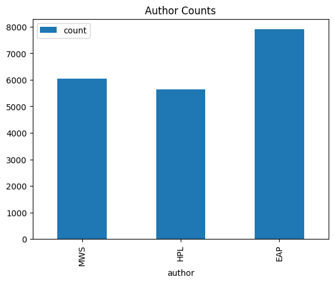

```python
import matplotlib.pyplot as plt
import pandas as pd

# Show counts of each author
print("Author Counts:")
author_counts_df = train_df.select("author").groupBy("author").count()
author_counts_df.show()
author_counts_df.toPandas().plot(kind='bar', x='author', y='count', title='Author Counts')
plt.show()
```

#### **Text Preprocessing**

Perform tasks like tokenization and stopwords removal to clean text data.

- Tokenize - split the text into individual words aka tokens.
- Remove stop.words - frequently used pronouns and personal references.
  - Top ten include: I, you, he, she, it, we, they, me, him, her
  - *There are couple of ways to remove stop words from the text data. One way is to use the `StopWordsRemover` class from the `pyspark.ml.feature` module.*
- Lemmatization - convert words to their root (optional).
  - Lemmatization is a text normalization technique that reduces words to their base or dictionary form (lemma). Use to reduce inflected or derived words to their root form for better analysis and modeling outcomes.
  - *We have multiple ways to lemmatize the text data. One way is to use the `WordNetLemmatizer` class from the `nltk` library. Lemmatization is very helpful as it helps to reduce words to their base forms, allowing for more accurate analysis and identification of common word forms.*

```python
import sys
print("Driver Python:", sys.executable, sys.version)
conf = spark.sparkContext.getConf()
print("spark.pyspark.python:", conf.get("spark.pyspark.python"))
print("spark.pyspark.driver.python:", conf.get("spark.pyspark.driver.python"))
```

```
Driver Python: /Users/jared/.pyenv/versions/3.10.16/bin/python 3.10.16 (main, Jun  9 2025, 19:05:54) [Clang 17.0.0 (clang-1700.0.13.5)]
spark.pyspark.python: /Users/jared/.pyenv/versions/3.10.16/bin/python
spark.pyspark.driver.python: /Users/jared/.pyenv/versions/3.10.16/bin/python
```

```python
# Prepare the NLTK resources
import nltk
from nltk.corpus import stopwords, wordnet
from nltk.stem import WordNetLemmatizer
import warnings
warnings.filterwarnings('ignore')

# Download the NLTK corpus if not already downloaded
nltk.download('stopwords')
nltk.download('wordnet')
nltk.download('omw-1.4')
nltk.download('punkt')
nltk.download('averaged_perceptron_tagger')
nltk.download('punkt_tab')
```

```
True
```

```python
from pyspark.ml.feature import Tokenizer
from pyspark.sql import functions
from pyspark.sql.functions import udf
from pyspark.sql.types import StringType
import string


# Get the list of stopwords
stop_words = set(stopwords.words('english'))
lemmatizer = WordNetLemmatizer()

def remove_special_character(text : str) -> str:
    return text.translate(str.maketrans('', '', string.punctuation))

def remove_stopwords(text):
    if text:
        return ' '.join([word for word in text.split() if word.lower() not in stop_words])
    return ''

def get_wordnet_pos(treebank_tag):
    if treebank_tag.startswith('J'):
        return wordnet.ADJ
    elif treebank_tag.startswith('V'):
        return wordnet.VERB
    elif treebank_tag.startswith('N'):
        return wordnet.NOUN
    elif treebank_tag.startswith('R'):
        return wordnet.ADV
    else:
        return wordnet.NOUN  # default to noun

def lemmatize_text(text):
    tokens = nltk.word_tokenize(text)
    pos_tags = nltk.pos_tag(tokens)
    lemmatized = [lemmatizer.lemmatize(word, get_wordnet_pos(pos)) for word, pos in pos_tags]
    return ' '.join(lemmatized)

def preprocess_text(text):
    text = lemmatize_text(text)
    # text = remove_special_character(text)
    # text = remove_stopwords(text)
    return text


train_pd_df = train_df.toPandas()
train_pd_df['preprocessed_text'] = train_pd_df['text'].apply(lambda str: preprocess_text(str))
train_df = spark.createDataFrame(train_pd_df)

test_pd_df = test_df.toPandas()
test_pd_df['preprocessed_text'] = test_pd_df['text'].apply(lambda str: preprocess_text(str))
test_df = spark.createDataFrame(test_pd_df)


tokenizer = Tokenizer(inputCol="preprocessed_text", outputCol="tokens")

# Tokenize the text column
transformed_df = tokenizer.transform(train_df)
transformed_test_df = tokenizer.transform(test_df)

# # Show the first few rows of the filtered DataFrame
print("Tokenized Training DataFrame:\n")
transformed_df.select("tokens").show(3, truncate=False)
print("\nTokenized Test DataFrame:\n")
transformed_test_df.select("tokens").show(3, truncate=False)
```

```
Tokenized Training DataFrame:
```

```
+---------------------------------------------------------------------------------------------------------------------------------------------------------------------------------------------------------------------------------------------------------------------------------+
|tokens                                                                                                                                                                                                                                                                           |
+---------------------------------------------------------------------------------------------------------------------------------------------------------------------------------------------------------------------------------------------------------------------------------+
|[this, process, ,, however, ,, afford, me, no, mean, of, ascertain, the, dimension, of, my, dungeon, ;, a, i, might, make, it, circuit, ,, and, return, to, the, point, whence, i, set, out, ,, without, be, aware, of, the, fact, ;, so, perfectly, uniform, seem, the, wall, .]|
|[it, never, once, occur, to, me, that, the, fumbling, might, be, a, mere, mistake, .]                                                                                                                                                                                            |
|[in, his, left, hand, be, a, gold, snuff, box, ,, from, which, ,, a, he, caper, down, the, hill, ,, cut, all, manner, of, fantastic, step, ,, he, take, snuff, incessantly, with, an, air, of, the, great, possible, self, satisfaction, .]                                      |
+---------------------------------------------------------------------------------------------------------------------------------------------------------------------------------------------------------------------------------------------------------------------------------+
only showing top 3 rows

Tokenized Test DataFrame:

+-----------------------------------------------------------------------------------------------------------------------------------------------------------------------------------------------------------------------------------------------------------------------------------------------------------…
|tokens                                                                                                                                                                                                                                                                                                     …
+-----------------------------------------------------------------------------------------------------------------------------------------------------------------------------------------------------------------------------------------------------------------------------------------------------------…
|[still, ,, a, i, urge, our, leave, ireland, with, such, inquietude, and, impatience, ,, my, father, think, it, best, to, yield, .]                                                                                                                                                                         …
|[if, a, fire, want, fanning, ,, it, could, readily, be, fan, with, a, newspaper, ,, and, a, the, government, grow, weak, ,, i, have, no, doubt, that, leather, and, iron, acquire, durability, in, proportion, ,, for, ,, in, a, very, short, time, ,, there, be, not, a, pair, of, bellow, in, all, rotter…
|[and, when, they, have, break, down, the, frail, door, they, find, only, this, :, two, cleanly, pick, human, skeleton, on, the, earthen, floor, ,, and, a, number, of, singular, beetle, crawl, in, the, shadowy, corner, .]                                                                               …
+-----------------------------------------------------------------------------------------------------------------------------------------------------------------------------------------------------------------------------------------------------------------------------------------------------------…
only showing top 3 rows
```

### **Stage 2: Feature Extraction**

5. Perform TF-IDF to quantify word importance `<term.frequency.inverse.doc.frequency>`
6. Normalize is scaling or standardizing the numerical features to a standard range or distribution.
   - In text mining, normalization vectorizes features with methods like TF-IDF, a numerical measurement, to ensure a consistent scale.
   - It handles variations in the magnitude of feature values impacting machine-learning algorithm performance. Normalize the features to ensure a similar scale and prevent features with larger values from dominating the analysis or modeling process.

```python
from pyspark.ml.feature import HashingTF, IDF
from pyspark.ml import Pipeline

# Limit the dataset, my environment kept running out of memory. I should get a better computer. (TODO: remove)
# transformed_df = transformed_df.limit(500) # Petty TODO: Remove this on a better computer
# transformed_test_df = transformed_test_df.limit(25) # Petty TODO: Remove this on a better computer

# Init HashingTF
##
   # can manipulate 'numFeatures' field in the constructor to potentially see different results
   # once we implement the Machine Learning phase. That constructor call would look something like:
   # hashingtf = HashingTF(inputCol="tokens", outputCol="raw_frequencies", numFeatures=10000)
   #     - Default value is 262144
##
hashingtf = HashingTF(inputCol="tokens", outputCol="raw_frequencies")

# Init IDF
idf = IDF(inputCol="raw_frequencies", outputCol="features")

# Build pipeline
pipeline = Pipeline(stages=[hashingtf, idf])

# Fit and transform
model = pipeline.fit(transformed_df)
tfidf = model.transform(transformed_df)
model_test = pipeline.fit(transformed_test_df)
tfidf_test = model_test.transform(transformed_test_df)

# Show the first few rows of the tf-idf transformed dataframe
print("TF-IDF normalized features:")
tfidf.select("features").show(3, truncate=False)
print("\nTest set also transformed (truncated):")
tfidf_test.select("features").show(3)
```

```
TF-IDF normalized features:
+-----------------------------------------------------------------------------------------------------------------------------------------------------------------------------------------------------------------------------------------------------------------------------------------------------------…
|features                                                                                                                                                                                                                                                                                                   …
+-----------------------------------------------------------------------------------------------------------------------------------------------------------------------------------------------------------------------------------------------------------------------------------------------------------…
|(262144,[8732,19036,20901,27576,30950,34188,38308,45404,46899,50001,88590,89717,91767,95889,100941,102036,107107,108541,117491,131709,141331,142239,145207,148880,167503,183339,183938,186312,209518,214862,219087,219915,221027,237388,240944,248200,256468,261675],[7.397357266296501,2.036730623534044,3…
|(262144,[15313,17046,27576,30950,39275,45404,48448,50001,95889,107107,113673,121401,145207,252843,256468],[5.382454245754237,5.77139005191119,0.8152167139347949,1.425457874683359,7.802822374404665,0.044969586283172255,1.3425267602333695,2.072722591431091,0.31194406616128567,0.7931876316013579,3.607…
|(262144,[4106,22370,25217,28338,33860,42404,45404,48648,49120,55639,62790,75292,95889,98424,101169,102006,107107,112947,126466,141331,143202,145207,170414,199176,219087,224255,227860,232367,239343,245523,250855,261845,261870],[4.764270103667746,5.349664422931245,3.7932190406376556,7.802822374404665…
+-----------------------------------------------------------------------------------------------------------------------------------------------------------------------------------------------------------------------------------------------------------------------------------------------------------…
only showing top 3 rows

Test set also transformed (truncated):
```

```
25/07/28 07:16:10 WARN DAGScheduler: Broadcasting large task binary with size 4.0 MiB
25/07/28 07:16:10 WARN DAGScheduler: Broadcasting large task binary with size 4.0 MiB
```

```
+--------------------+
|            features|
+--------------------+
|(262144,[4629,190...|
|(262144,[1623,490...|
|(262144,[24980,25...|
+--------------------+
only showing top 3 rows
```

### **Stage 3: Machine Learning**

7. Perform train\test split.
8. Perform algorithmic analysis to assess and predict test labels.
   - a. Use as many algorithms as you need to get a good answer.
   - b. Supervised: logistic regression, random forest, support vector machines, etc.
   - c. Unsupervised: K-means, dimensionality reduction, PCA, etc.

```python
from pyspark.ml.classification import DecisionTreeClassifier, LogisticRegression, RandomForestClassifier, NaiveBayes
from pyspark.ml.evaluation import MulticlassClassificationEvaluator
from pyspark.ml.feature import StringIndexer
from pyspark.ml.tuning import CrossValidator, ParamGridBuilder, CrossValidatorModel

# Transform authors into numeric (0-2)
#tfidf.show(3)
#tfidf_test.show(3)
label_indexer = StringIndexer(inputCol="author", outputCol="label")
labeled_df = label_indexer.fit(tfidf).transform(tfidf)
#labeled_df.show(3)

# Make a test set so we can have an idea of how the model does
train_data, val_data = labeled_df.randomSplit([0.8, 0.2], seed=42)

dt = DecisionTreeClassifier()
lr = LogisticRegression()
rf = RandomForestClassifier()
nb = NaiveBayes()

accuracy_eval = MulticlassClassificationEvaluator(metricName='accuracy')
f1_eval = MulticlassClassificationEvaluator(metricName='f1')
grid = ParamGridBuilder().addGrid(nb.smoothing, [0.5, 1, 1.5, 2]).build()

model = dt.fit(train_data)
dt_prediction = model.transform(val_data)
dt_accuracy_score = accuracy_eval.evaluate(dt_prediction)
dt_f1_score = f1_eval.evaluate(dt_prediction)
print('Decision Tree Accuracy: ', dt_accuracy_score, '\nF1: ', dt_f1_score)
dtImportances = model.featureImportances

model = lr.fit(train_data)
lr_prediction = model.transform(val_data)
lr_accuracy_score = accuracy_eval.evaluate(lr_prediction)
lr_f1_score = f1_eval.evaluate(lr_prediction)
print('Logistic Regression Accuracy: ', lr_accuracy_score, '\nF1: ', lr_f1_score)
lrImportances = model.coefficientMatrix

model = rf.fit(train_data)
rf_prediction = model.transform(val_data)
rf_accuracy_score = accuracy_eval.evaluate(rf_prediction)
rf_f1_score = f1_eval.evaluate(rf_prediction)
print('Random Forest Accuracy: ', rf_accuracy_score, '\nF1: ', rf_f1_score)
rfImportances = model.featureImportances

model = nb.fit(train_data)
nb_prediction = model.transform(val_data)
nb_accuracy_score = accuracy_eval.evaluate(nb_prediction)
nb_f1_score = f1_eval.evaluate(nb_prediction)
print('Naive Bayes Accuracy: ', nb_accuracy_score, '\nF1: ', nb_f1_score)
nbImportances = model.theta

cv = CrossValidator(estimator=nb, estimatorParamMaps=grid, evaluator=accuracy_eval, parallelism=2)
model = cv.fit(labeled_df)
cv_prediction = model.transform(labeled_df)
cv_accuracy_score = accuracy_eval.evaluate(cv_prediction)
cv_f1_score = f1_eval.evaluate(cv_prediction)
print('Cross Validator NB Accuracy:', cv_accuracy_score, '\nF1: ', cv_f1_score)
best_model = model.bestModel
smoothing = best_model.getSmoothing()
cvImportances = f'Best smoothing parameter found by Cross Validator: {smoothing}'
```

[output not shown]

[output cut: 12 more lines]

[output not shown]

```
Decision Tree Accuracy:  0.510660700184259
F1:  0.49989926710253074
```

[output not shown]

[output cut: 42 more lines]

[output not shown]

```
Logistic Regression Accuracy:  0.7457225585680443
F1:  0.7457210793333771
```

[output not shown]

[output cut: 12 more lines]

[output not shown]

```
Random Forest Accuracy:  0.41932087391418793
F1:  0.2634327339985048
```

```
25/07/28 07:19:53 WARN DAGScheduler: Broadcasting large task binary with size 4.1 MiB
25/07/28 07:19:54 WARN DAGScheduler: Broadcasting large task binary with size 4.1 MiB
25/07/28 07:19:54 WARN DAGScheduler: Broadcasting large task binary with size 10.1 MiB
25/07/28 07:19:55 WARN DAGScheduler: Broadcasting large task binary with size 10.1 MiB
```

```
Naive Bayes Accuracy:  0.8370623848381153
F1:  0.8371148668772619
```

[output not shown]

```
Cross Validator NB Accuracy: 0.9246131058787477
F1:  0.9246895861427589
```

### **Stage 4: Evaluation & Visualization**

9. Choose a metric strategy to assess algorithmic performance like accuracy, precision, recall, or F1 score.
10. Visualize confusion matrix, correlations, and similar.
11. Identify important features contributing to classification.
12. Write a 2-3 sentence minimum of findings, learnings, and what you would do next.

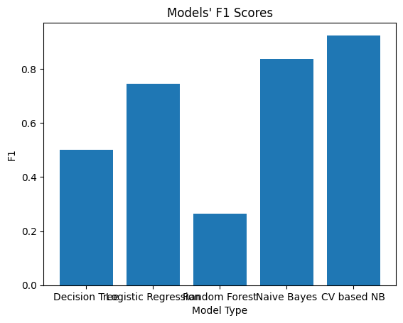

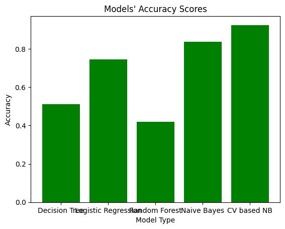

```
25/07/28 07:20:07 WARN DAGScheduler: Broadcasting large task binary with size 4.1 MiB
25/07/28 07:20:07 WARN DAGScheduler: Broadcasting large task binary with size 4.1 MiB
25/07/28 07:20:07 WARN DAGScheduler: Broadcasting large task binary with size 4.7 MiB
```

```
Decision Tree Confusion Matrix:
prediction  EAP  MWS  HPL
label
EAP         989  148  406
MWS         430  350  410
HPL         379   86  601
```

```
25/07/28 07:20:08 WARN DAGScheduler: Broadcasting large task binary with size 4.7 MiB
25/07/28 07:20:08 WARN DAGScheduler: Broadcasting large task binary with size 4.2 MiB
```

```
Logistic Regression Confusion Matrix:
prediction   EAP  MWS  HPL
label
EAP         1160  227  156
MWS          191  902   97
HPL          181  114  771
```

```
25/07/28 07:20:08 WARN DAGScheduler: Broadcasting large task binary with size 4.1 MiB
25/07/28 07:20:08 WARN DAGScheduler: Broadcasting large task binary with size 10.1 MiB
```

```
Random Forest Confusion Matrix:
prediction   EAP  MWS  HPL
label
EAP         1540    3    0
MWS         1140   50    0
HPL         1063    0    3
```

```
25/07/28 07:20:09 WARN DAGScheduler: Broadcasting large task binary with size 10.1 MiB
25/07/28 07:20:09 WARN DAGScheduler: Broadcasting large task binary with size 10.1 MiB
```

```
Naive Bayes Confusion Matrix:
prediction   EAP   MWS  HPL
label
EAP         1286   167   90
MWS          122  1011   57
HPL          123    60  883
Cross Validator based NB Confusion Matrix:
prediction   EAP   MWS   HPL
label
EAP         7294   435   171
MWS          310  5647    87
HPL          319   154  5162
We use HashingTF in our computation, so we cannot identify the which word corresponds to an important feature.
We can get descriptive statistics about the hashed features and determine how significant certain indices are against others in the Sparse Vector, coefficient matrix, or theta.
Decision Tree max value: 0.2194843888795673, mean: 3.814697265625e-06, difference: 0.21948057418230169.
Logistic Regression Coefficient Matrix:
class 0 (one of the authors): Least: -229.0579990671621, Mean: -0.014443138205124452, Difference: 229.04355592895695.
class 1 (one of the authors): Least: -202.9340306568158, Mean: -0.008548286845508915, Difference: 202.9254823699703.
class 2 (one of the authors): Least: -30.27769313341363, Mean: 0.022991425050633358, Difference: 30.300684558464265.
Random Forest max value: 0.0637793205690683, mean: 3.8146972656249975e-06, difference: 0.06377550587180268.
Naive Bayes Theta Matrix:
class 0 (one of the authors): Least: -13.646656365374696, Mean: -13.513538131310824, Difference: 0.1331182340638719.
class 1 (one of the authors): Least: -13.504825639938831, Mean: -13.405679383623628, Difference: 0.09914625631520302.
class 2 (one of the authors): Least: -13.512343276683792, Mean: -13.38808775618743, Difference: 0.12425552049636224.
Best smoothing parameter found by Cross Validator: 2.0
```

```
25/07/28 07:20:09 WARN DAGScheduler: Broadcasting large task binary with size 10.1 MiB
```

```python
#Bar chart representing F1 values for each model:
plt.bar(["Decision Tree" , "Logistic Regression" , "Random Forest" , "Naive Bayes", "CV based NB"] , [dt_f1_score , lr_f1_score , rf_f1_score , nb_f1_score, cv_f1_score])
plt.xlabel("Model Type")
plt.ylabel("F1")
plt.title("Models' F1 Scores")
plt.show()

#Bar chart representing accuracy values for each model:
plt.bar(["Decision Tree" , "Logistic Regression" , "Random Forest" , "Naive Bayes", "CV based NB"] , [dt_accuracy_score , lr_accuracy_score , rf_accuracy_score , nb_accuracy_score, cv_accuracy_score] , color = "green")
plt.xlabel("Model Type")
plt.ylabel("Accuracy")
plt.title("Models' Accuracy Scores")
plt.show()

import numpy as np
#utility function to print a matrix from a numpy array
#df is a pandas dataframe
def showAsMatrix(df , title):
    matrix = plt.matshow(df)
    asArray = confusionMatrix.to_numpy()
    for (i, j), value in np.ndenumerate(asArray):
        plt.text(j , i , str(value) , ha = 'center' , va = 'center' , color = 'white')
    plt.title(title)
    plt.show()

#confusion Matrices:
def printConfusionMatrix(predictionType , prefixString):
    confusionDF = predictionType.groupBy("label", "prediction").count()
    confusionDFPandas = confusionDF.toPandas()
    #StringIndexer docs: "By default, this is ordered by label frequencies so the most frequent label gets index 0."
    confusionMatrix = confusionDFPandas.pivot_table(index='label', columns='prediction', values='count', aggfunc='sum', fill_value=0)
    #We change the x and y axes to author names. We use StringIndexer to convert author names to numbers. StringIndexer assigns an index to a string
    #based on its frequency. The most occuring string is assigned 0, next most occurring, 1, etc. Therefore, we know that:
    namesMap = {0.0 : "EAP" , 1.0 : "MWS" , 2.0 : "HPL"}
    confusionMatrix = confusionMatrix.rename(index = namesMap , columns = namesMap)
    print(f"{prefixString}:")
    print(confusionMatrix)
    #showAsMatrix(confusionMatrix , prefixString)

printConfusionMatrix(dt_prediction , "Decision Tree Confusion Matrix")
printConfusionMatrix(lr_prediction , "Logistic Regression Confusion Matrix")
printConfusionMatrix(rf_prediction , "Random Forest Confusion Matrix")
printConfusionMatrix(nb_prediction , "Naive Bayes Confusion Matrix")
printConfusionMatrix(cv_prediction , "Cross Validator based NB Confusion Matrix")

#important Features:

#This function prints stats for the given importance data structure. The goal is to try to find some interesting information about an otherwise
#ambiguous data structure.
#We get the maximum value of the sparse vector (representing the most hit hashed index) and
def getImportantFeaturesSV(sparseVector , sparseVectorName):
    spMax = max(sparseVector.values)
    spMean = sum(sparseVector.values) / sparseVector.size
    print(f"{sparseVectorName} max value: {spMax}, mean: {spMean}, difference: {spMax - spMean}.")

def getImportantFeaturesM(matrix , matrixName):
    print(f"{matrixName}:")
    asArray = matrix.toArray()
    classes = asArray.shape[0]
    for i in range(classes):
        currentClass = asArray[i]
        classMin = currentClass.min()
        classMean = currentClass.mean()
        difference = classMean - classMin
        print(f"class {i} (one of the authors): Least: {classMin}, Mean: {classMean}, Difference: {difference}.")

print("We use HashingTF in our computation, so we cannot identify the which word corresponds to an important feature.")
print("We can get descriptive statistics about the hashed features and determine how significant certain indices are against others in the Sparse Vector, coefficient matrix, or theta.")

getImportantFeaturesSV(dtImportances , "Decision Tree")
getImportantFeaturesM(lrImportances , "Logistic Regression Coefficient Matrix")
getImportantFeaturesSV(rfImportances , "Random Forest")
getImportantFeaturesM(nbImportances , "Naive Bayes Theta Matrix")
print(cvImportances)
```

## **CONCLUSIONS**

In this assignment, we explored the improvement for the accuracy by changing the text preprocessing process and hyperparameter tuning.

- With old process, our model achieved Naive Bayes Accuracy is `0.8239 (82.4%)`. We applied 3 preprocessing techniques orderedly:
  1. Lemmatization
  2. Special character removal
  3. Stopwords removal